# A cross-sectional study of the diet and oral health of elite athletes in Ireland

# Introduction

# Statistical analysis

misc re results: - REport 1. .Cluster, 2. Regression 3. Density plots - Others is FB minus selected cariogenic/foods of interest. Originally we defined cariogenic adn non but then changed to foods of intertest as we wanted more fine grained food groups of intertest, water (FBdental analysis.csv) - Foodbook grouping Rmd (manually define cariogenic etc) - Data augmentation - took origibnal FB file and joined and summarised by food group - Density plot in paper (of cluster eg starch)- shows ’%’conusmption levles by comparison of distribution of density (better thann just counto f individuals as low in one cluster, accounts for diff numbers in clusters) x axis =amonunt in g, y -count/total number (subjects)

# Methods

## Survey data

Field data collection was carried out at the athletes training centres using physiotherapy beds for examination, an external light source (Daray LED x200 medical examination light), and disposable dental examination kits (2156 – dental examination Pack. Clonallon). A digital data collection (DDC) form including the dental charts and questionnaire data was created using the KoboToolbox (KBTB) platform (preview available: https://kf.kobotoolbox.org/#/forms/a9bpX9EogskyPLJFghQzTq). The DDC forms were completed using Apple iPads (Apple Inc., CA, USA) on KBTB. Athletes self-completed 24-hour dietary recalls (24HR) using a separate DDC tool- Foodbook24 (FB24). Participants performed one interviewer-guided 24HR on the day of dental examination. They were subsequently invited to complete 3 additional recalls. To pseudonymise participants’ datafiles unique ID key code values were generated and randomly assigned to participants by creating a Microsoft Excel file to link FB24 and KBTB datasets. Participant ID codes were assigned and manually transferred from the keycode file to the web form and consent form for each participant.

Two core datasets were created from KBTB (oral health examination, socio-demographic and dietary-health behavioural data) and FB24 (multiple 24HR). The raw csv files were imported into R for data processing pre-analysis.

EDA/descriptive overall for both-

All food groups were mapped to a ‘short group code name’ to facilitate analysis of food groups. Consumption statistics (mean, median, SD, maximum, minimum, sum) for all nutrients were computed and summarised by subject, meal and food group level. Descriptive summaries of all nutrients was carried out for all completed recalls. Analysis of the distinct recalls indicated no substantial difference in food consumption across different recall, thus all recall data was retained. *(THIS IS PROBABLY FOR RESULTS/DISC, appendix for regression lines)* The FB24 data set was transformed and saved as RDS file for further analysis.

### Consumption descriptions

- `total_consumptions` the total number of consumptions across all recalls
- `max_daily_consumptions` the maximum number of consumptions in a single recall (i.e. one day) across all recalls
- `mean_intake` the mean daily intake across the recalls that the food group is consumed. Note this a mean daily intake rather than a mean consumption intake. All consumptions in a day were summed and an average taken which only includes the days of consumption.
- `max_intake` and `min_intake`are the maximum and minimum daily intake
- `avg_intake` the average intake which includes recalls when the food was not consumed.

total_consumptions = sum(consumption), max_daily_consumptions = max(consumption), mean_intake = mean(intake), max_intake = max(intake), min_intake = min(intake), recalls = n_distinct(`Recall #`), sum_intake = sum(intake), avg_intake = sum(intake) / max(`Recall #`), (see FBgrouping Rmd code and add this to APPEDIX)

Both KBTB and FB24 RDS files were joined and data prepared for cluster analysis. Two athletes were removed (Gymnast and Triathlete) as there was only one from each sport and one athlete had incomplete dietary data (?). Potentially cariogenic food groups were selected (dentalFoodGroups) and described as ‘cariogenic’ based on previously published literature (CITE PM etc-NB add to APPENDIX table in Grouping FB24 Rmd -food group/ dental analyis csv). All other food groups were collapsed into one group and described as ‘non-cariogenic’ and water intake was categorised separately. For this analysis, nutrients were limited to carbohydrate, sugars, starch and energy intake. Meal types were collapsed to ‘snack’ or ‘main meal’.

## EDA/descriptives of groups by gender

## GLM based on cluster group

# RESULTS

## Dental caries/ICDAS

### Post-processings

- Kobo data is post-processed and ICDAS categories are collapsed into counts.
- FoodBook24 data is summarised at subject, meal, food group level and for this analysis we only take in account subset of the food groups ????You mean cluster/reg?

```r
library(dduh.ds)
library(tidyverse)  # data manipulation
library(cluster)    # clustering algorithms
library(factoextra) # clustering algorithms & visualization
library(caret)
config <- dduh.ds::load_config(config_file = "../../configs/ea_data.yaml")

koboData <- readRDS(config$data_repositories$kobo)
fbDentalIntake <- readRDS(config$data_repositories$foodbook_daily_intakes_dental_cario)
fbDentalIntakeLong <- readRDS(config$data_repositories$foodbook_daily_intakes_dental_long)
```

```r
selectedGroups <- fbDentalIntakeLong |>
  group_by(GroupCodeShortId, GroupCodeShort, User, MealShort) |>
  reframe(total_consumptions = max(total_consumptions)) |>
  group_by(GroupCodeShortId, GroupCodeShort) |>
  reframe(total_consumptions = sum(total_consumptions)) |>
  arrange(as.numeric(GroupCodeShortId))

knitr::kable(selectedGroups, caption = "Selected food group for dental interest")
```

Selected food group for dental interest

| GroupCodeShortId | GroupCodeShort | total_consumptions |
| --- | --- | --- |
| 1 | Beverages Sugar-sweetened | 71 |
| 2 | Biscuits, Cakes and Savouries | 119 |
| 3 | Breads, Rolls and Scones | 154 |
| 4 | Breakfast cereals | 186 |
| 5 | Fruit drinks and others | 82 |
| 6 | Yoghurt & yoghurt drinks | 77 |
| 7 | Sugars, Confectionary and Non Chocolate Confectionary | 144 |
| 8 | Sugars, Confectionary and Cereal-type Bars | 35 |
| 9 | Sugars, Confectionary and Chocolate Confectionary | 62 |
| 10 | Sugars, Confectionary and Crisps and savoury Snacks | 28 |
| 11 | Sugars, Confectionary and Jam, marmalade, lemon curd | 24 |
| 12 | Creams, Ice-creams and Desserts | 34 |
| 13 | Dietary Supplements | 246 |
| 14 | Beverages Water | 209 |
| NA | Others | 2022 |

We create a combined profile between the dental examination and the summarised food diary

```r
values_cols = c(
  "sum_mean_intake",
  "avg_intake",
  "total_consumptions"
)
fbIntakeNutrientsLong <- fbDentalIntakeLong |>
  select(User,
         GroupCodeShort,
         MealShort,
         Nutrient,
         recalls,
         total_consumptions,
         mean_intake,
         max_intake,
         sum_intake) |>
  mutate(
    avg_consumptions_per_recall=total_consumptions/recalls,
    avg_intake=sum_intake/recalls
  )  |> filter(!is.na(MealShort))
```

## Outliers for food intakes

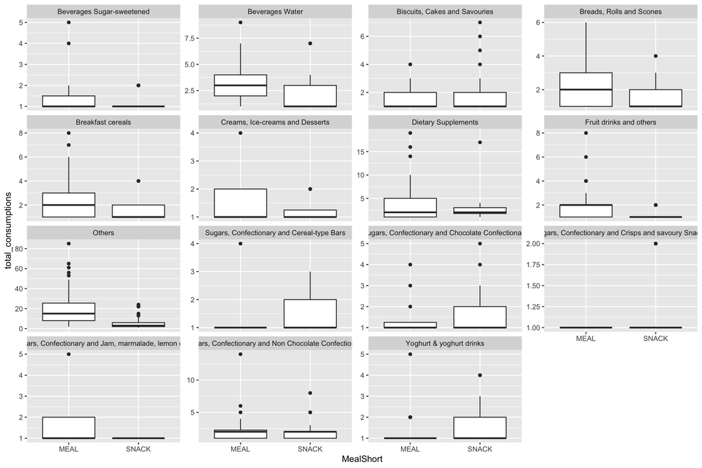

```r
dentalNutrients <- c("ENERGY_KCAL",
                     "CHO",
                     "SUGARS",
                     "STARCH"
                     )

ggplot(fbIntakeNutrientsLong |> filter(Nutrient == 'SUGARS')) +
  geom_boxplot(aes(x=MealShort, y=total_consumptions)) +
  facet_wrap(.~GroupCodeShort, scales = "free_y")
```

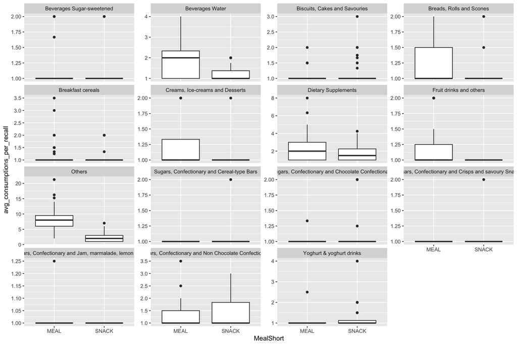

```r
ggplot(fbIntakeNutrientsLong |> filter(Nutrient == 'SUGARS')) +
  geom_boxplot(aes(x=MealShort, y=avg_consumptions_per_recall)) +
  facet_wrap(.~GroupCodeShort, scales = "free_y")
```

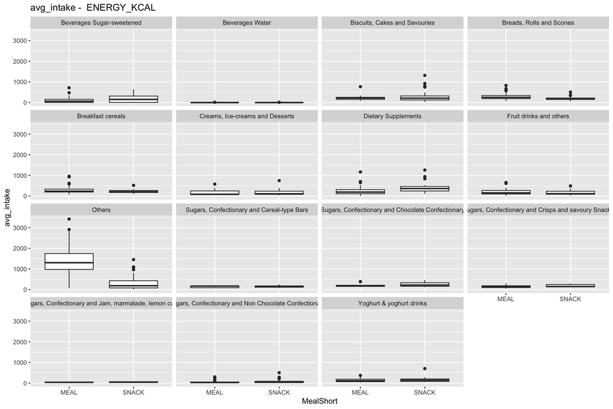

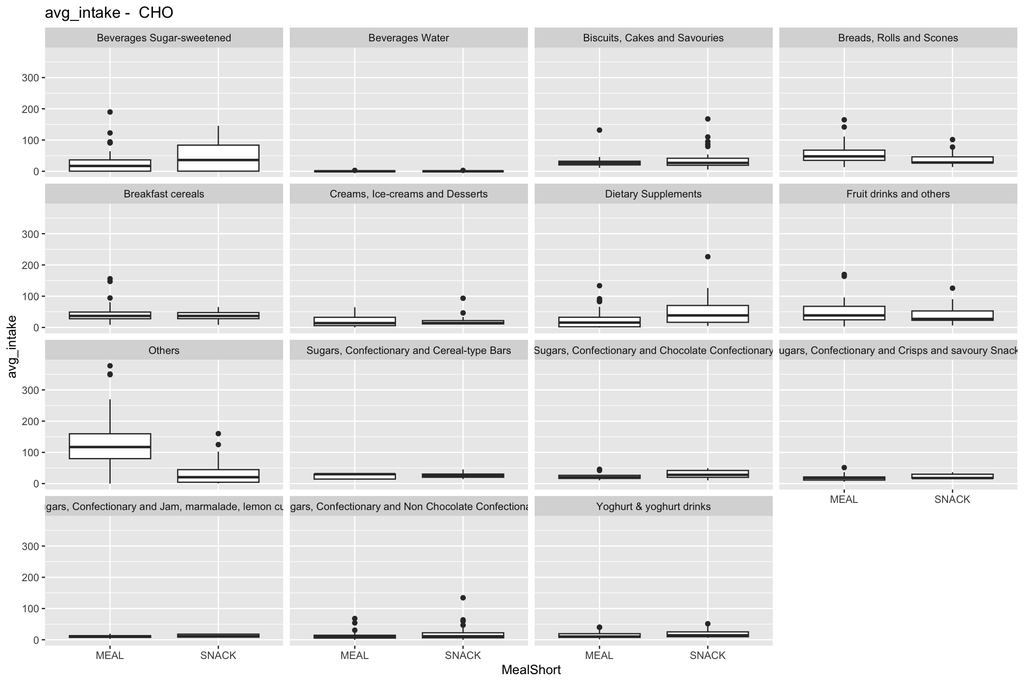

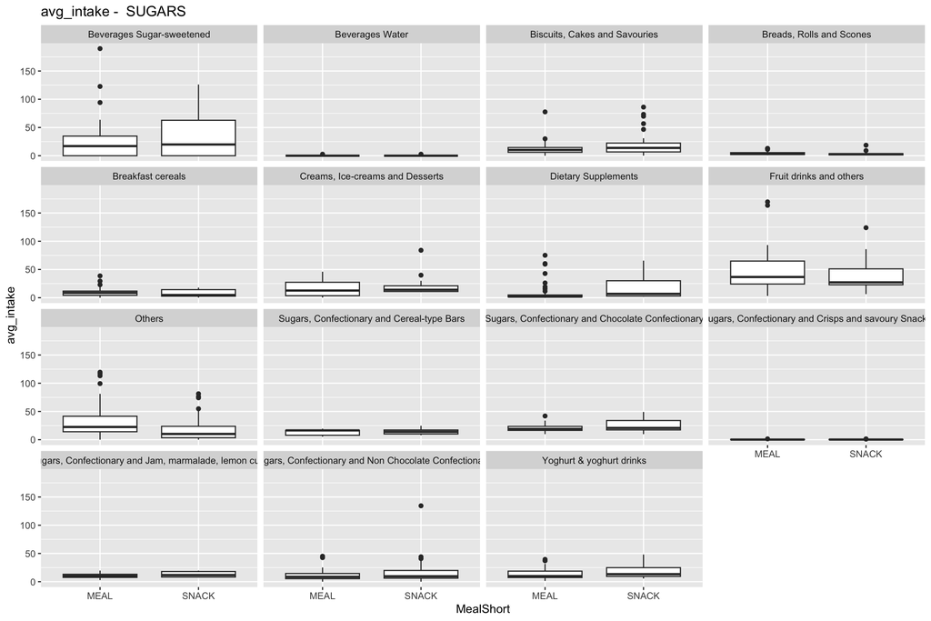

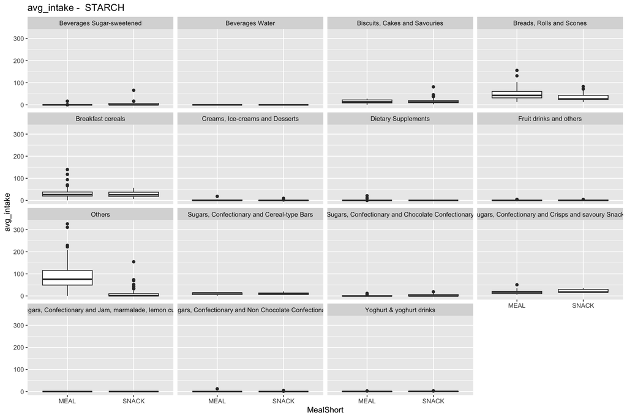

```r
for (nutrient in dentalNutrients) {
p <- ggplot(fbIntakeNutrientsLong |> filter(Nutrient == nutrient)) +
  geom_boxplot(aes(x=MealShort, y=avg_intake)) +
  facet_wrap(.~GroupCodeShort) +
  ggtitle(paste("avg_intake - ", nutrient))
print(p)
}
```

We consider only cariogenic and non-cariogenic for total consumptions Water is not counted

```r
fbIntakeNutrients <- fbDentalIntakeLong |>
  group_by(User, MealShort, Nutrient, GroupCodeShortIsCariogenic) |>
  reframe(
    total_consumptions=sum(total_consumptions),
    sum_mean_intake=sum(mean_intake),
    avg_intake=sum(sum_intake)/max(recalls)
  )  |> filter(!is.na(MealShort)) |>
  pivot_wider(
    values_from = all_of(values_cols),
    names_from = c(MealShort, Nutrient, GroupCodeShortIsCariogenic),
    values_fill = 0
  ) |>
  mutate(
    total_consumptions = total_consumptions_MEAL_CHO_Cariogenic +
      total_consumptions_MEAL_CHO_NonCariogenic
  )
```

```r
combinedProfiles <-
  koboData |>
  left_join(fbDentalIntake,
            by = join_by(participant_id == User),
            keep = TRUE) |>
  filter(!is.na(User)) |>
  select(-User)


combinedProfilesNutrients <-
    koboData |>
  left_join(fbIntakeNutrients,
            by = join_by(participant_id == User),
            keep = TRUE) |>
  filter(!is.na(User)) |>
  select(-User)
```

# Clustering

```r
is.boolean.str <- function(x) {
  isBool <- FALSE
  if (is.character(x)) {
    if (length(unique(x)) == 2) {
      isBool <- TRUE
    }
  }

  isBool
}

to.01 <- function(x) {
  as.numeric(factor(x)) - 1
}

is.cost.val <- function(x){
  length(unique(x)) == 1
}


fbConsumptionCols <- colnames(fbDentalIntake)[-1]
fbMeanStats <- fbConsumptionCols[grep("avg|total", fbConsumptionCols)]
koboDental <-
combinedProfiles |>
  select(
         # count_icdas_score_1_3,
         # count_icdas_score_1_5,
         # count_icdas_score_1_6,
         # count_icdas_score_1_7,
         # count_icdas_score_1_8,
         # count_icdas_score_1_4,
         # count_icdas_score_1_3,
         # count_icdas_score_1_8,
         # count_icdas_score_1_97,
         count_icdas_score_2_2,
         count_icdas_score_2_3,
         count_icdas_score_2_4,
         count_icdas_score_2_5,
         count_icdas_score_2_6,
         age,
         gender,
         ethnicity,
         # tobacco,
         # smokeless_tobacco,
         # ecig_nicotine,
         # ecig_without_nicotine,
         # clean_morning,
         # clean_night,
         # clean_before_nap,
         # clean_after_nap,
         # clean_other,
         # manual_tb,
         # powered_tb,
         # interdental_aids,
         # nonfluoridated_tp,
         # fluoridated_tp,
         # mouthwash,
         # gum,
         # gum_shield,
         # last_dental_visit,
         # sport_remap,
         # trauma_status,
         # trauma_number_teeth,
         # describe_oralhealth,
         # duration_elite,
         # teeth_affect_eating,
         # teeth_affect_relaxing,
         # teeth_affect_smiling,
         # teeth_affect_participation,
         # pain_12months,
         # frequency_cakes,
         # frequency_sweets,
         # frequency_nondiet_drinks,
         # frequency_diet_drinks,
         # bars_before_competition,
         # bars_after_competition,
         # bars_during_competition,
         # bars_before_training,
         # bars_during_training,
         # bars_after_training,
         # gels_before_training,
         # gels_during_training,
         # gels_after_training,
         # gels_before_competition,
         # gels_during_competition,
         # gels_after_competition,
         # drinks_before_training,
         # drinks_during_training,
         # drinks_after_training,
         # drinks_before_competitions,
         # drinks_during_competitions,
         # drinks_after_competitions,
         # last_dental_visit,
         all_of(fbMeanStats)
         ) |>
#  mutate(sport_remap=if_else(is.na(sport_remap), 'UNKNOWN',  sport_remap)) |>
  #mutate(across(where(is.numeric), function(x){(x-min(x))/(max(x)-min(x))})) |>
  mutate(across(where(is.numeric), function(x){as.vector(scale(x))})) |>
  mutate(across(where(is.boolean.str), to.01))

dummyEncoder <- caret::dummyVars(~., koboDental |> select(where(is.character)))
dummyCols <- predict(dummyEncoder, koboDental |> select(where(is.character)))



koboDentalEncoded <-
  koboDental |>
  select(-where(is.character)) |>
  bind_cols(dummyCols) |>
  select(-where(is.cost.val))


#rownames(koboDentalEncoded) <- paste("s", seq_along(koboData$examiner_id))
```

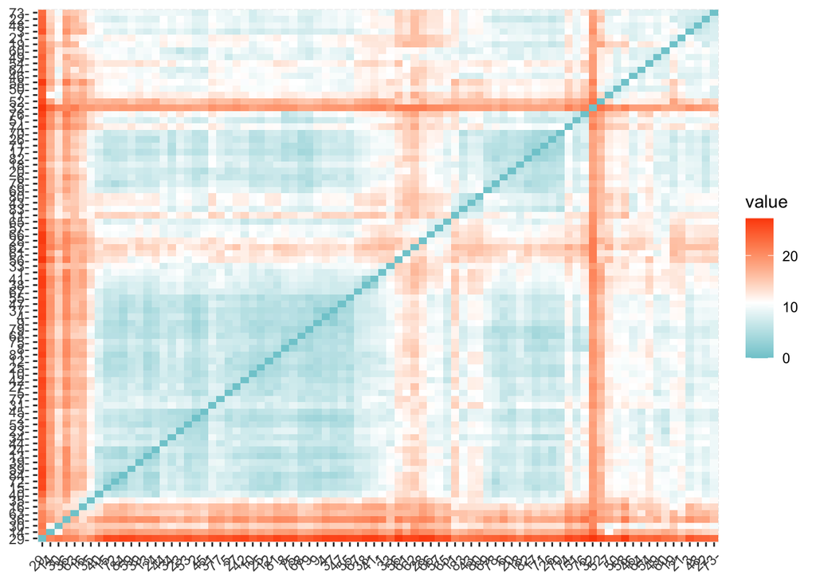

```r
distance <- get_dist(koboDentalEncoded)
fviz_dist(distance, gradient = list(low = "#00AFBB", mid = "white", high = "#FC4E07"))
```

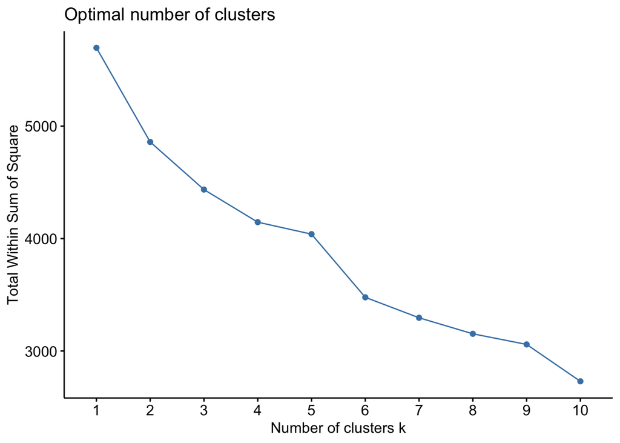

```r
fviz_nbclust(koboDentalEncoded, cluster::clara, method = "wss")
```

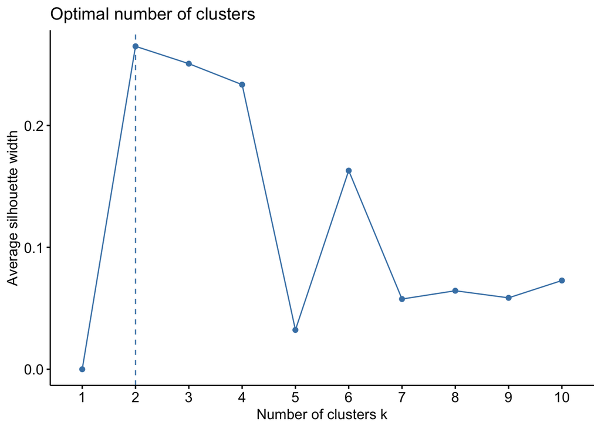

```r
fviz_nbclust(koboDentalEncoded, cluster::clara, method = "silhouette")
```

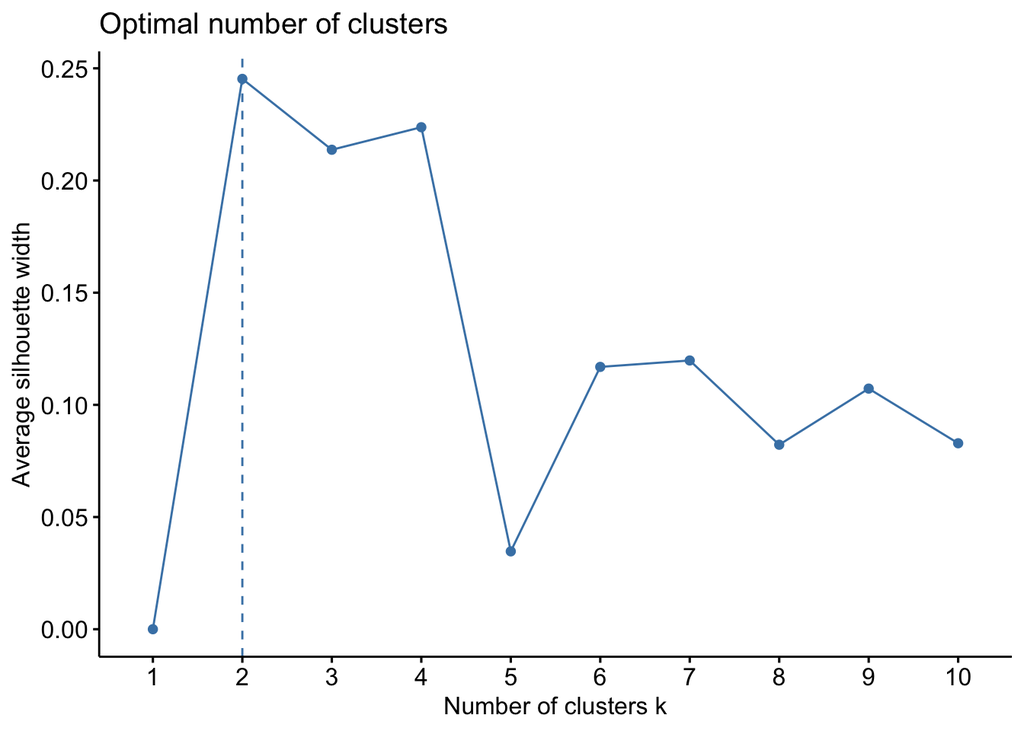

```r
fviz_nbclust(koboDentalEncoded, kmeans, method = "silhouette")
```

```r
k3 <- kmeans(koboDentalEncoded, centers = 2, nstart = 5)

summary(k3)
```

```
##              Length Class  Mode
## cluster       84    -none- numeric
## centers      152    -none- numeric
## totss          1    -none- numeric
## withinss       2    -none- numeric
## tot.withinss   1    -none- numeric
## betweenss      1    -none- numeric
## size           2    -none- numeric
## iter           1    -none- numeric
## ifault         1    -none- numeric
```

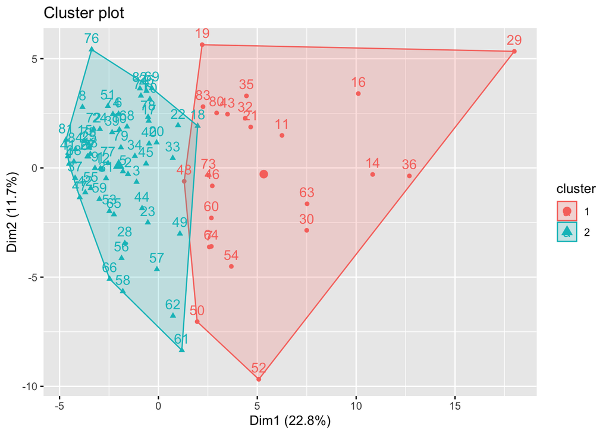

```r
fviz_cluster(k3, data = koboDentalEncoded)
```

```r
koboDataK3Numeric <-
  combinedProfilesNutrients |>
  mutate(
    combined_icdas_score_2 = count_icdas_score_2_2 + count_icdas_score_2_3 + count_icdas_score_2_4 +
    count_icdas_score_2_5 + count_icdas_score_2_6) |>
  select(contains("avg_intake_MEAL"), contains("avg_intake_SNACK"), combined_icdas_score_2, participant_id) |>
  mutate(cluster = k3$cluster) |>
  select(where(is.numeric), participant_id, cluster) |>
  pivot_longer(cols=-c("participant_id", "cluster"), names_to = "variable") |>
#  filter(variable %in% colnames(koboDental)) |>
  mutate(cluster=as_factor(cluster))
```

We are going to rename `avg_intake` to `mean_daily_intake` to be consistent with our definition

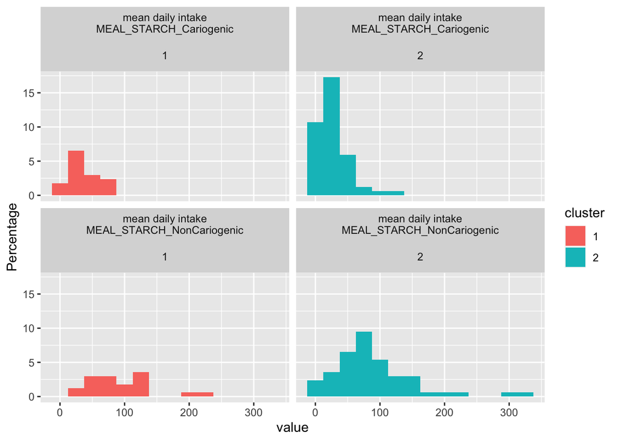

```r
ggplot(
  koboDataK3Numeric |>
    filter(
      str_starts(variable, "avg_intake_MEAL_STARCH") &
        !str_ends(variable, "Water") &
        !str_ends(variable, "_NA")
    ) |>
    mutate(variable = str_replace(
      variable, "avg_intake_", "mean daily intake\n"
    ))
) +
  geom_histogram(aes(
    x = value,
    y = after_stat(count / sum(count)) * 100.0,
    fill = cluster
  ), binwidth = 25) +
  facet_wrap(~ variable + cluster) +
  ylab("Percentage")
```

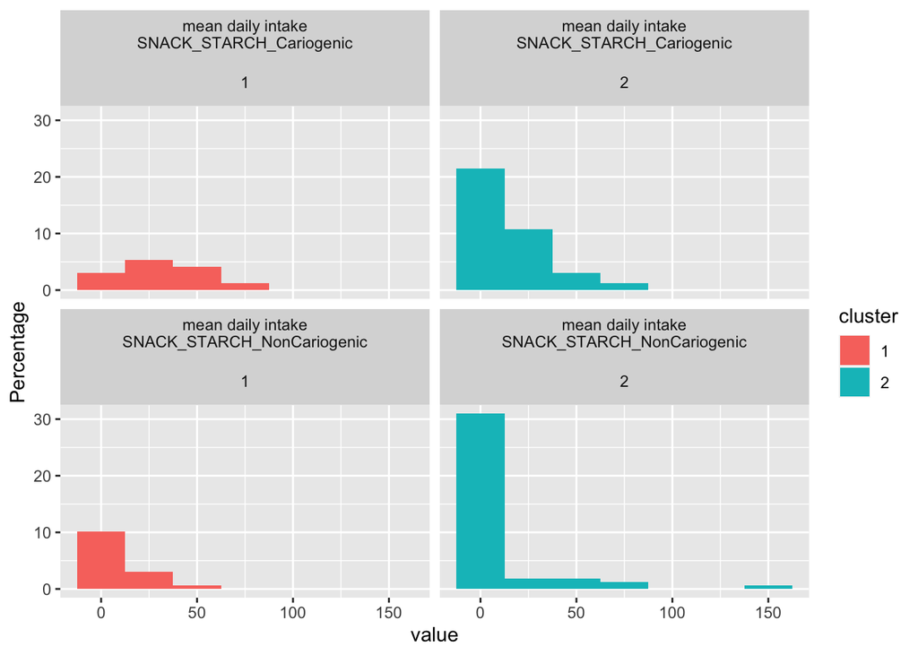

```r
ggplot(
  koboDataK3Numeric |>
    filter(
      str_starts(variable, "avg_intake_SNACK_STARCH") &
        !str_ends(variable, "Water") &
        !str_ends(variable, "_NA")
    ) |>
    mutate(variable = str_replace(
      variable, "avg_intake_", "mean daily intake\n"
    ))

) +
  geom_histogram(aes(
    x = value,
    y = after_stat(count / sum(count)) * 100.0,
    fill = cluster
  ), binwidth = 25) +
  facet_wrap(~ variable + cluster) +
  ylab("Percentage")
```

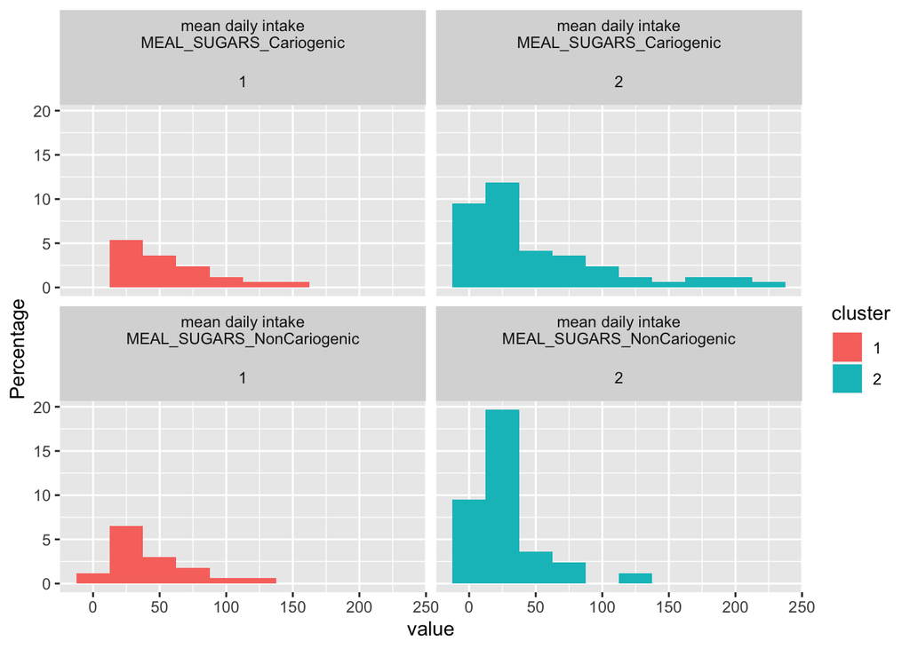

```r
ggplot(
  koboDataK3Numeric |> filter(
    str_starts(variable, "avg_intake_MEAL_SUGARS")  &
      !str_ends(variable, "Water") &
      !str_ends(variable, "_NA")
  ) |>
    mutate(variable = str_replace(
      variable, "avg_intake_", "mean daily intake\n"
    ))

) +
  geom_histogram(aes(
    x = value,
    y = after_stat(count / sum(count)) * 100.0,
    fill = cluster
  ), binwidth = 25) +
  facet_wrap(~ variable + cluster) +
  ylab("Percentage")
```

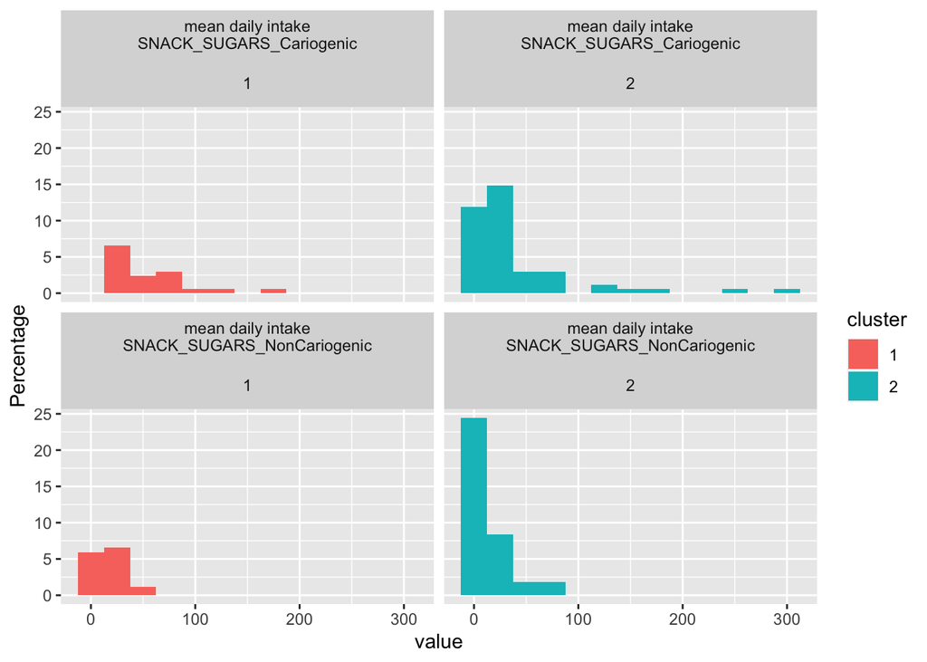

```r
ggplot(
  koboDataK3Numeric |> filter(
    str_starts(variable, "avg_intake_SNACK_SUGARS")  &
      !str_ends(variable, "Water") &
      !str_ends(variable, "_NA")
  ) |>
    mutate(variable = str_replace(
      variable, "avg_intake_", "mean daily intake\n"
    ))
) +
  geom_histogram(aes(
    x = value,
    y = after_stat(count / sum(count)) * 100.0,
    fill = cluster
  ), binwidth = 25) +
  facet_wrap(~ variable + cluster) +
  ylab("Percentage")
```

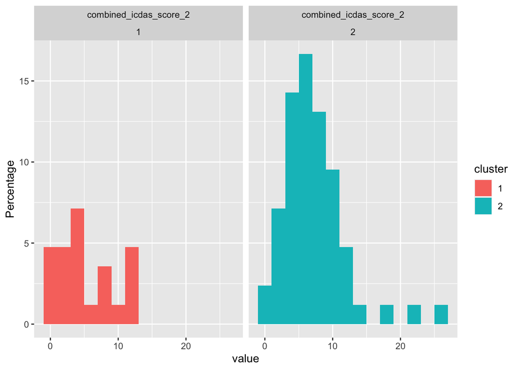

```r
ggplot(koboDataK3Numeric |> filter(
  str_starts(variable, "combined_icdas_score_2")  &
    !str_ends(variable, "Water")
)) +
  geom_histogram(aes(
    x = value,
    y = after_stat(count / sum(count)) * 100,
    fill = cluster
  ), binwidth = 2) +
  facet_wrap(~ variable + cluster) +
  ylab("Percentage")
```

```r
library(nnet)
fbMeanStats <- colnames(fbIntakeNutrients)[grep(
  "avg_intake_MEAL_STARCH_Cariogenic|avg_intake_MEAL_STARCH_NonCariogenic|avg_intake_SNACK_STARCH_Cariogenic|avg_intake_SNACK_STARCH_NonCariogenic|avg_intake_MEAL_SUGARS_Cariogenic|avg_intake_MEAL_SUGARS_NonCariogenic|avg_intake_SNACK_SUGARS_Cariogenic|avg_intake_SNACK_SUGARS_NonCariogenic",
  colnames(fbIntakeNutrients))]

lmData <- combinedProfilesNutrients |>
  mutate(cluster=as.factor(k3$cluster-1)) |>
  select(
         # count_icdas_score_1_3,
         # count_icdas_score_1_8,
         # count_icdas_score_1_97,
         count_icdas_score_2_2,
         count_icdas_score_2_3,
         count_icdas_score_2_4,
         count_icdas_score_2_5,
         count_icdas_score_2_6,
         age,
         gender,
         all_of(fbMeanStats),

        cluster
) |>
  mutate(
  # count_icdas_score_1 = count_icdas_score_1_3 + count_icdas_score_1_8 + count_icdas_score_1_97,
  count_icdas_score_2 = count_icdas_score_2_2 + count_icdas_score_2_3 + count_icdas_score_2_4 +
    count_icdas_score_2_5 + count_icdas_score_2_6
) |>
select(-c(
  # count_icdas_score_1_3,
  #        count_icdas_score_1_8,
  #        count_icdas_score_1_97,
         count_icdas_score_2_2,
         count_icdas_score_2_3,
         count_icdas_score_2_4,
         count_icdas_score_2_5,
         count_icdas_score_2_6,
)) |>
  mutate(cluster = factor(cluster))

#model <- multinom(cluster~., data=lmData)
#summary(model)
#lmData <- koboDentalEncoded |> mutate(cluster=k3$cluster)

model = glm(cluster~., data = lmData, family = binomial)

summary(model)
```

```
##
## Call:
## glm(formula = cluster ~ ., family = binomial, data = lmData)
##
## Coefficients:
##                                         Estimate Std. Error z value Pr(>|z|)
## (Intercept)                            0.7455699  1.9870087   0.375  0.70750
## age                                    0.0147013  0.0737985   0.199  0.84210
## genderMale                             1.1040508  0.6330460   1.744  0.08115 .
## avg_intake_MEAL_STARCH_Cariogenic     -0.0090067  0.0137261  -0.656  0.51171
## avg_intake_MEAL_STARCH_NonCariogenic   0.0021816  0.0060656   0.360  0.71909
## avg_intake_MEAL_SUGARS_Cariogenic      0.0062261  0.0065668   0.948  0.34307
## avg_intake_MEAL_SUGARS_NonCariogenic  -0.0221992  0.0143058  -1.552  0.12072
## avg_intake_SNACK_STARCH_Cariogenic    -0.0441572  0.0155577  -2.838  0.00454 **
## avg_intake_SNACK_STARCH_NonCariogenic  0.0148125  0.0230077   0.644  0.51970
## avg_intake_SNACK_SUGARS_Cariogenic    -0.0004444  0.0060571  -0.073  0.94151
## avg_intake_SNACK_SUGARS_NonCariogenic -0.0107000  0.0173098  -0.618  0.53648
## count_icdas_score_2                    0.1089697  0.0849561   1.283  0.19961
## ---
## Signif. codes:  0 '***' 0.001 '**' 0.01 '*' 0.05 '.' 0.1 ' ' 1
##
## (Dispersion parameter for binomial family taken to be 1)
##
##     Null deviance: 98.618  on 83  degrees of freedom
## Residual deviance: 76.510  on 72  degrees of freedom
## AIC: 100.51
##
## Number of Fisher Scoring iterations: 5
```

```r
#model$residuals
confint.default(model)
```

```
##                                              2.5 %       97.5 %
## (Intercept)                           -3.148895568  4.640035342
## age                                   -0.129941119  0.159343787
## genderMale                            -0.136696606  2.344798275
## avg_intake_MEAL_STARCH_Cariogenic     -0.035909265  0.017895884
## avg_intake_MEAL_STARCH_NonCariogenic  -0.009706771  0.014070038
## avg_intake_MEAL_SUGARS_Cariogenic     -0.006644616  0.019096860
## avg_intake_MEAL_SUGARS_NonCariogenic  -0.050238158  0.005839741
## avg_intake_SNACK_STARCH_Cariogenic    -0.074649826 -0.013664656
## avg_intake_SNACK_STARCH_NonCariogenic -0.030281696  0.059906691
## avg_intake_SNACK_SUGARS_Cariogenic    -0.012316060  0.011427271
## avg_intake_SNACK_SUGARS_NonCariogenic -0.044626587  0.023226673
## count_icdas_score_2                   -0.057541176  0.275480591
```

```r
exp(model$coefficients[-1])
```

```
##                                   age                            genderMale
##                             1.0148099                             3.0163601
##     avg_intake_MEAL_STARCH_Cariogenic  avg_intake_MEAL_STARCH_NonCariogenic
##                             0.9910337                             1.0021840
##     avg_intake_MEAL_SUGARS_Cariogenic  avg_intake_MEAL_SUGARS_NonCariogenic
##                             1.0062455                             0.9780454
##    avg_intake_SNACK_STARCH_Cariogenic avg_intake_SNACK_STARCH_NonCariogenic
##                             0.9568035                             1.0149227
##    avg_intake_SNACK_SUGARS_Cariogenic avg_intake_SNACK_SUGARS_NonCariogenic
##                             0.9995557                             0.9893571
##                   count_icdas_score_2
##                             1.1151286
```

```r
library(broom)

tidy(model, conf.int = TRUE, exponentiate = TRUE)
```

| term | estimate | std.error | statistic | p.value | conf.low | conf.high |
| --- | --- | --- | --- | --- | --- | --- |
| (Intercept) | 2.1076422 | 1.987008683 | 0.3752223 | 0.707495177 | 0.04034006 | 108.8770298 |
| age | 1.0148099 | 0.073798526 | 0.1992090 | 0.842099221 | 0.88158532 | 1.1822166 |
| genderMale | 3.0163601 | 0.633046041 | 1.7440293 | 0.081153983 | 0.90109905 | 11.1812891 |
| avg_intake_MEAL_STARCH_Cariogenic | 0.9910337 | 0.013726056 | -0.6561747 | 0.511711733 | 0.96372417 | 1.0175725 |
| avg_intake_MEAL_STARCH_NonCariogenic | 1.0021840 | 0.006065624 | 0.3596717 | 0.719092683 | 0.99059357 | 1.0154892 |
| avg_intake_MEAL_SUGARS_Cariogenic | 1.0062455 | 0.006566824 | 0.9481178 | 0.343069513 | 0.99383177 | 1.0202080 |
| avg_intake_MEAL_SUGARS_NonCariogenic | 0.9780454 | 0.014305850 | -1.5517575 | 0.120720270 | 0.94987092 | 1.0055340 |
| avg_intake_SNACK_STARCH_Cariogenic | 0.9568035 | 0.015557727 | -2.8382836 | 0.004535687 | 0.92590578 | 0.9851829 |
| avg_intake_SNACK_STARCH_NonCariogenic | 1.0149227 | 0.023007664 | 0.6438071 | 0.519700541 | 0.97814953 | 1.0681098 |
| avg_intake_SNACK_SUGARS_Cariogenic | 0.9995557 | 0.006057084 | -0.0733678 | 0.941513443 | 0.98749794 | 1.0126534 |

[output cut: 2 more lines]

```r
library(janitor)
combinedProfileClusterd <- combinedProfilesNutrients |>
  mutate(cluster=as.factor(k3$cluster)) |>
  mutate(
  # count_icdas_score_1 = count_icdas_score_1_3 + count_icdas_score_1_8 + count_icdas_score_1_97,
  count_icdas_score_2 = count_icdas_score_2_2 + count_icdas_score_2_3 + count_icdas_score_2_4 +
    count_icdas_score_2_5 + count_icdas_score_2_6
)

combinedProfileClusterd |>
  tabyl(cluster, gender) |>
  adorn_percentages("row") |>
  adorn_pct_formatting(digits = 1) |>
  adorn_ns("front")
```

|  | cluster | Female | Male |
| --- | --- | --- | --- |
| 1 | 1 | 11 (47.8%) | 12 (52.2%) |
| 2 | 2 | 20 (32.8%) | 41 (67.2%) |

```r
combinedProfileClusterd |>
  tabyl(cluster, count_icdas_score_2_4) |>
  adorn_percentages("row") |>
  adorn_pct_formatting(digits = 1) |>
  adorn_ns("front")
```

|  | cluster | 0 | 1 | 2 | 3 | 4 | 5 | 6 | 7 |
| --- | --- | --- | --- | --- | --- | --- | --- | --- | --- |
| 1 | 1 | 12 (52.2%) | 4 (17.4%) | 2 (8.7%) | 4 (17.4%) | 0 (0.0%) | 0 (0.0%) | 1 (4.3%) | 0 (0.0%) |
| 2 | 2 | 30 (49.2%) | 14 (23.0%) | 8 (13.1%) | 3 (4.9%) | 1 (1.6%) | 1 (1.6%) | 1 (1.6%) | 3 (4.9%) |

```r
combinedProfileClusterd |>
  tabyl(cluster, sport) |>
  adorn_percentages("row") |>
  adorn_pct_formatting(digits = 1) |>
  adorn_ns("front")
```

|  | cluster | Boxing | Other | Rowing | Swimming |
| --- | --- | --- | --- | --- | --- |
| 1 | 1 | 5 (21.7%) | 9 (39.1%) | 8 (34.8%) | 1 (4.3%) |
| 2 | 2 | 17 (27.9%) | 27 (44.3%) | 13 (21.3%) | 4 (6.6%) |

```r
combinedProfileClusterd |>
  tabyl(cluster, total_consumptions_SNACK_SUGARS_Cariogenic) |>
  adorn_percentages("row") |>
  adorn_pct_formatting(digits = 1) |>
  adorn_ns("front")
```

|  | cluster | 0 | 1 | 2 | 3 | 4 | 5 | 6 | 7 | 8 | 9 | 10 | 14 | 16 | 21 | 24 |
| --- | --- | --- | --- | --- | --- | --- | --- | --- | --- | --- | --- | --- | --- | --- | --- | --- |
| 1 | 1 | 0 (0.0%) | 1 (4.3%) | 1 (4.3%) | 1 (4.3%) | 4 (17.4%) | 0 (0.0%) | 1 (4.3%) | 2 (8.7%) | 3 (13.0%) | 1 (4.3%) | 3 (13.0%) | 2 (8.7%) | 2 (8.7%) | 1 (4.3%) | 1 (4.3%) |
| 2 | 2 | 12 (19.7%) | 9 (14.8%) | 9 (14.8%) | 13 (21.3%) | 5 (8.2%) | 3 (4.9%) | 3 (4.9%) | 2 (3.3%) | 2 (3.3%) | 1 (1.6%) | 2 (3.3%) | 0 (0.0%) | 0 (0.0%) | 0 (0.0%) | 0 (0.0%) |